# Much Ado About Nothing

### PMM - predicitive mean matching

```r
pmm_MNAR <- mice(MNAR_iris, method = "pmm", m =5, maxit = 5, seed = 123, print = FALSE)
pmm_MNAR_complete <- complete(pmm_MNAR, 5) # Please note this is a simplified approach, and that best practice requires pool and testing against a model. However, as a demonstration it is still effective.
```

```r
MNAR_pmm_imp_summary <- pmm_MNAR_complete %>%
  dplyr::select(`Sepal.Length`, `Petal.Length`) %>% # selecting to avoid summaries of shadow variables.
  tbl_summary( statistic = list(
      all_continuous() ~ "{mean} ({sd})",
      all_categorical() ~ "{n} / {N} ({p}%)"
    ))

tbl_merge(tbls = list(original_summary, MNAR_summary, MNAR_del_summary, MNAR_mean_imp_summary, MNAR_lm_imp_summary, MNAR_pmm_imp_summary),
          tab_spanner = c("Original", "MNAR", "MNAR deleted missing", "MNAR mean imputed", "MNAR linear model imp", "MNAR pmm imputed")) # using to compare summaries of original and missing data.
```

| **Characteristic** | Original **N = 150**<sup>1</sup> | MNAR **N = 150**<sup>2</sup> | MNAR deleted missing **N = 105**<sup>2</sup> | MNAR mean imputed **N = 150**<sup>2</sup> | MNAR linear model imp **N = 150**<sup>2</sup> | MNAR pmm imputed **N = 150**<sup>2</sup> |
| --- | --- | --- | --- | --- | --- | --- |
| Sepal.Length | 5.84 (0.83) | 5.84 (0.83) | 5.80 (0.61) | 5.84 (0.83) | 5.84 (0.83) | 5.84 (0.83) |
| Sepal.Width | 3.06 (0.44) |  |  |  |  |  |
| Petal.Length | 3.76 (1.77) | 3.81 (1.42) | 3.81 (1.42) | 3.81 (1.18) | 3.90 (1.69) | 3.69 (1.57) |
| Unknown |  | 45 |  |  |  |  |
| Petal.Width | 1.20 (0.76) |  |  |  |  |  |
| Species |  |  |  |  |  |  |
| setosa | 50 / 150 (33%) |  |  |  |  |  |
| versicolor | 50 / 150 (33%) |  |  |  |  |  |
| virginica | 50 / 150 (33%) |  |  |  |  |  |

<sup>1</sup> Mean (SD); n / N (%)  
<sup>2</sup> Mean (SD)

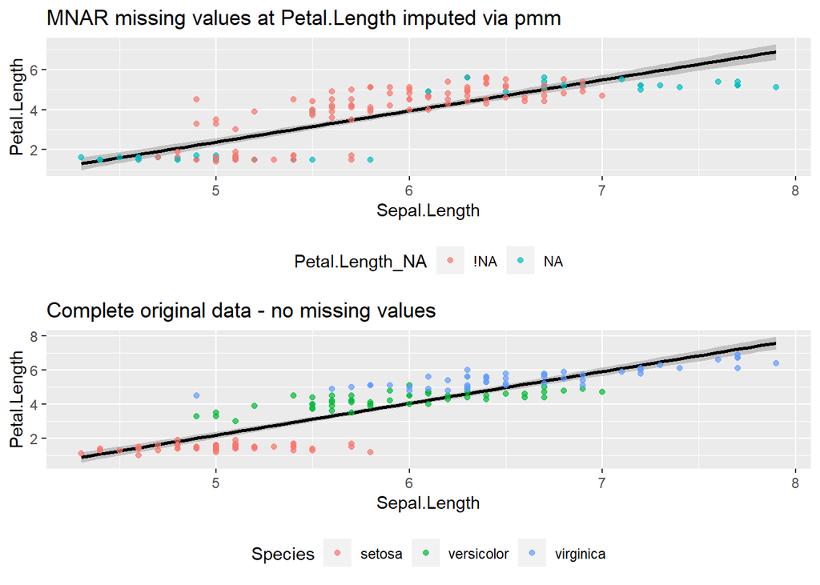

```r
vis_pmm_imp <- ggplot(pmm_MNAR_complete, aes(x = Sepal.Length, y = Petal.Length)) +
  geom_smooth(method = "lm", formula = y ~ x, color = "black", alpha = .5) +
  geom_point(aes(color = Petal.Length_NA), alpha = .7)+
  theme(legend.position = "bottom") +
  labs(title = "MNAR missing values at Petal.Length imputed via pmm")

grid.arrange(vis_pmm_imp, vis_complete) # Using grid.arrange() to compare plots, lets see the difference between a full data, and MCAR data
```

```r
model_MNAR_pmm_imp <- lm(Petal.Length ~ Sepal.Length, pmm_MNAR_complete) # Establishing model




MNAR_pmm_imp <- tbl_regression(model_MNAR_pmm_imp) %>%
  modify_column_unhide(column = std.error) %>%
  add_glance_table(include = c(r.squared, adj.r.squared,
                               statistic, df.residual, p.value))

tbl_merge(tbls = list(Original_model, MNAR, MNAR_del, MNAR_mean_imp, MNAR_lm_imp, MNAR_pmm_imp),
          tab_spanner = c("Original", "MNAR", "MNAR missing deleted", "MNAR mean imputation", "MNAR linear model imputation", "MNAR predictive mean matching imputation"))
```

| **Characteristic** | Original **Beta** | Original **SE**<sup>1</sup> | Original **95% CI**<sup>1</sup> | Original **p-value** | MNAR **Beta** | MNAR **SE**<sup>1</sup> | MNAR **95% CI**<sup>1</sup> | MNAR **p-value** | MNAR missing deleted **Beta** | MNAR missing deleted **SE**<sup>1</sup> | MNAR missing deleted **95% CI**<sup>1</sup> | MNAR missing deleted **p-value** | MNAR mean imputation **Beta** | MNAR mean imputation **SE**<sup>1</sup> | MNAR mean imputation **95% CI**<sup>1</sup> | MNAR mean imputation **p-value** | MNAR linear model imputation **Beta** | MNAR linear model imputation **SE**<sup>1</sup> | MNAR linear model imputation **95% CI**<sup>1</sup> | MNAR linear model imputation **p-value** | MNAR predictive mean matching imputation **Beta** | MNAR predictive mean matching imputation **SE**<sup>1</sup> | MNAR predictive mean matching imputation **95% CI**<sup>1</sup> | MNAR predictive mean matching imputation **p-value** |
| --- | --- | --- | --- | --- | --- | --- | --- | --- | --- | --- | --- | --- | --- | --- | --- | --- | --- | --- | --- | --- | --- | --- | --- | --- |
| Sepal.Length | 1.9 | 0.086 | 1.7, 2.0 | <0.001 | 1.8 | 0.138 | 1.6, 2.1 | <0.001 | 1.8 | 0.138 | 1.6, 2.1 | <0.001 | 0.70 | 0.102 | 0.50, 0.90 | <0.001 | 1.8 | 0.071 | 1.7, 2.0 | <0.001 | 1.6 | 0.089 | 1.4, 1.7 | <0.001 |
| R² | 0.760 |  |  |  | 0.633 |  |  |  | 0.633 |  |  |  | 0.241 |  |  |  | 0.819 |  |  |  | 0.673 |  |  |  |
| Adjusted R² | 0.758 |  |  |  | 0.629 |  |  |  | 0.629 |  |  |  | 0.236 |  |  |  | 0.818 |  |  |  | 0.671 |  |  |  |
| Statistic | 469 |  |  |  | 177 |  |  |  | 177 |  |  |  | 46.9 |  |  |  | 670 |  |  |  | 305 |  |  |  |
| Residual df | 148 |  |  |  | 103 |  |  |  | 103 |  |  |  | 148 |  |  |  | 148 |  |  |  | 148 |  |  |  |
| p-value | <0.001 |  |  |  | <0.001 |  |  |  | <0.001 |  |  |  | <0.001 |  |  |  | <0.001 |  |  |  | <0.001 |  |  |  |

<sup>1</sup> SE = Standard Error, CI = Confidence Interval

### But what can we do about MNAR?!

The simplest recommend approach is to use *auxiliary variables*; that is, additional variable that can explain the pattern of missing data, and thus turning it from *MNAR* to *MAR*. This can be easier said than done. The best way to prepare is to use your theoretical knowledge of your variables to determine in advance what variable may be of use for inferring patterns of missingness. When working with data collected from people, the demographic data may also be of use!

For today, we are going to imagine that another researcher conveniently had access to a data set which included the `Petal.Width` and corresponding `ID` variable. What a hero.

We are using the PMM method of imputing to compare for this example.

```r
petal_width_id <- iris %>% select(Petal.Width, Sepal.Width, Species) %>% mutate(ID = row_number())
MNAR_rescue <- merge(MNAR_iris, petal_width_id, by = "ID")


pmm_rescue <- mice(MNAR_rescue, method = "pmm", m =5, maxit = 5, seed = 123, print = FALSE)
pmm_rescue_complete <- complete(pmm_rescue, 5) # Please note this is a simplified approach, and that best practice requires pool and testing against a model. However, as a demonstration it is still effective.
```

```r
MNAR_rescue_imp_summary <- pmm_rescue_complete %>%
  dplyr::select(`Sepal.Length`, `Sepal.Width`, `Petal.Length`, `Petal.Width`, `Species`) %>% # selecting to avoid summaries of shadow variables.
  tbl_summary( statistic = list(
      all_continuous() ~ "{mean} ({sd})",
      all_categorical() ~ "{n} / {N} ({p}%)"
    ))

tbl_merge(tbls = list(original_summary, MNAR_summary, MNAR_pmm_imp_summary, MNAR_rescue_imp_summary),
          tab_spanner = c("Original", "MNAR", "MNAR pmm imputed", "MNAR rescue PMM")) # using to compare summaries of original and missing data.
```

| **Characteristic** | Original **N = 150**<sup>1</sup> | MNAR **N = 150**<sup>2</sup> | MNAR pmm imputed **N = 150**<sup>2</sup> | MNAR rescue PMM **N = 150**<sup>1</sup> |
| --- | --- | --- | --- | --- |
| Sepal.Length | 5.84 (0.83) | 5.84 (0.83) | 5.84 (0.83) | 5.84 (0.83) |
| Sepal.Width | 3.06 (0.44) |  |  | 3.06 (0.44) |
| Petal.Length | 3.76 (1.77) | 3.81 (1.42) | 3.69 (1.57) | 3.69 (1.57) |
| Unknown |  | 45 |  |  |
| Petal.Width | 1.20 (0.76) |  |  | 1.20 (0.76) |
| Species |  |  |  |  |
| setosa | 50 / 150 (33%) |  |  | 50 / 150 (33%) |
| versicolor | 50 / 150 (33%) |  |  | 50 / 150 (33%) |
| virginica | 50 / 150 (33%) |  |  | 50 / 150 (33%) |

<sup>1</sup> Mean (SD); n / N (%)  
<sup>2</sup> Mean (SD)

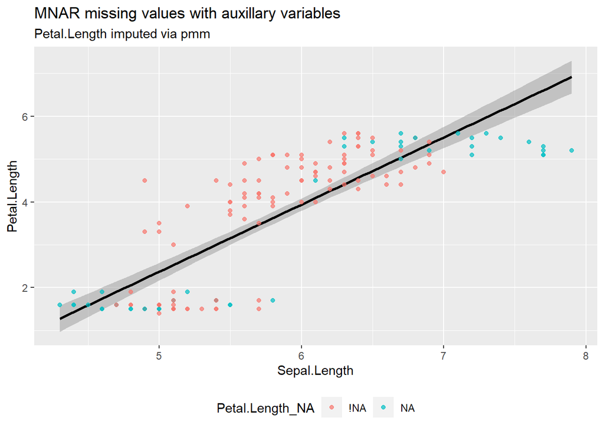

```r
vis_rescue_imp <- ggplot(pmm_rescue_complete, aes(x = Sepal.Length, y = Petal.Length)) +
  geom_smooth(method = "lm", color = "black", alpha = .5) +
  geom_point(aes(color = Petal.Length_NA), alpha = .7)+
  theme(legend.position = "bottom") +
  labs(title = "MNAR missing values with auxillary variables",
       subtitle =  "Petal.Length imputed via pmm")

vis_rescue_imp
```

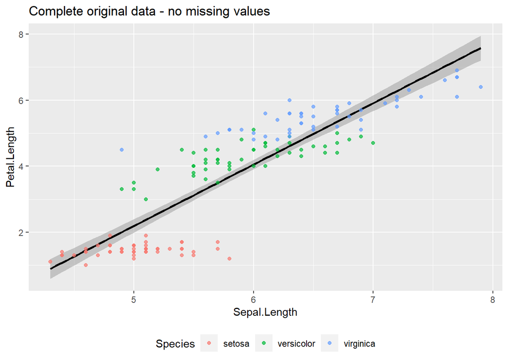

```r
vis_complete
```

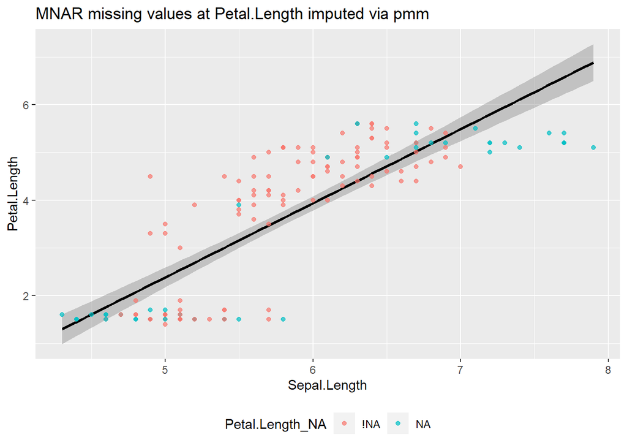

```r
vis_pmm_imp
```

```r
model_rescue_pmm_imp <- lm(Petal.Length ~ Sepal.Length, pmm_rescue_complete) # Establishing model


model_complete <- lm(Petal.Length ~ Sepal.Length, iris)# New original to compare more accurately

original_data_model <- tbl_regression(model_complete) %>%
  modify_column_unhide(column = std.error) %>%
  add_glance_table(include = c(r.squared, adj.r.squared,
                               statistic, df.residual, p.value))

MNAR_rescue_imp <- tbl_regression(model_rescue_pmm_imp) %>%
  modify_column_unhide(column = std.error) %>%
  add_glance_table(include = c(r.squared, adj.r.squared,
                               statistic, df.residual, p.value))

tbl_merge(tbls = list(original_data_model, MNAR, MNAR_pmm_imp, MNAR_rescue_imp ),
          tab_spanner = c("Original", "MNAR", "MNAR predictive mean matching imputation", "Rescued MNAR PMM"))
```

| **Characteristic** | Original **Beta** | Original **SE**<sup>1</sup> | Original **95% CI**<sup>1</sup> | Original **p-value** | MNAR **Beta** | MNAR **SE**<sup>1</sup> | MNAR **95% CI**<sup>1</sup> | MNAR **p-value** | MNAR predictive mean matching imputation **Beta** | MNAR predictive mean matching imputation **SE**<sup>1</sup> | MNAR predictive mean matching imputation **95% CI**<sup>1</sup> | MNAR predictive mean matching imputation **p-value** | Rescued MNAR PMM **Beta** | Rescued MNAR PMM **SE**<sup>1</sup> | Rescued MNAR PMM **95% CI**<sup>1</sup> | Rescued MNAR PMM **p-value** |
| --- | --- | --- | --- | --- | --- | --- | --- | --- | --- | --- | --- | --- | --- | --- | --- | --- |
| Sepal.Length | 1.9 | 0.086 | 1.7, 2.0 | <0.001 | 1.8 | 0.138 | 1.6, 2.1 | <0.001 | 1.6 | 0.089 | 1.4, 1.7 | <0.001 | 1.6 | 0.088 | 1.4, 1.7 | <0.001 |
| R² | 0.760 |  |  |  | 0.633 |  |  |  | 0.673 |  |  |  | 0.681 |  |  |  |
| Adjusted R² | 0.758 |  |  |  | 0.629 |  |  |  | 0.671 |  |  |  | 0.679 |  |  |  |
| Statistic | 469 |  |  |  | 177 |  |  |  | 305 |  |  |  | 316 |  |  |  |
| Residual df | 148 |  |  |  | 103 |  |  |  | 148 |  |  |  | 148 |  |  |  |
| p-value | <0.001 |  |  |  | <0.001 |  |  |  | <0.001 |  |  |  | <0.001 |  |  |  |

<sup>1</sup> SE = Standard Error, CI = Confidence Interval

And that is the end of part 1! Apologies if that was all rather heavy